# Impact of severe weather events on Public Health and the Economy

Faiyaz Hasan

June 21, 2016

## 1. Synopsis

In this document, we takes datasets from the U.S. National Oceanic and Atmospheric Administration’s storm database to find out which types of severe weather events lead to maximal (i) economic and (ii) public health damage.

## 2. Loading and processing data

```r
setwd("C:\\Users\\Windows\\Documents\\JHU_Data_Science\\Course_5\\Project_2") # Set Project_2 as the working directory
```

Set the database url, destination filename in the Project_2 folder and then load the data.

```r
URL <- "https://d396qusza40orc.cloudfront.net/repdata%2Fdata%2FStormData.csv.bz2" # Database URL
destfile <- "storm_data.csv.bz2" # destination file name
download.file(URL, destfile) # download file
```

Read data from the data file.

```r
storm_data <- read.csv(destfile) # Read in csv format data
```

Change column names to lower case.

```r
names(storm_data) <- tolower(names(storm_data)) # Change all field names to lowercase
```

Details of the data frame: dimensions, variable names, structure etc.

```r
dim(storm_data) # dimensions of storm data
```

```
## [1] 902297     37
```

```r
names(storm_data) # column names of storm data
```

```
##  [1] "state__"    "bgn_date"   "bgn_time"   "time_zone"  "county"
##  [6] "countyname" "state"      "evtype"     "bgn_range"  "bgn_azi"
## [11] "bgn_locati" "end_date"   "end_time"   "county_end" "countyendn"
## [16] "end_range"  "end_azi"    "end_locati" "length"     "width"
## [21] "f"          "mag"        "fatalities" "injuries"   "propdmg"
## [26] "propdmgexp" "cropdmg"    "cropdmgexp" "wfo"        "stateoffic"
## [31] "zonenames"  "latitude"   "longitude"  "latitude_e" "longitude_"
## [36] "remarks"    "refnum"
```

```r
str(storm_data) # structure of storm data
```

```
## 'data.frame':    902297 obs. of  37 variables:
##  $ state__   : num  1 1 1 1 1 1 1 1 1 1 ...
##  $ bgn_date  : Factor w/ 16335 levels "1/1/1966 0:00:00",..: 6523 6523 4242 11116 2224 2224 2260 383 3980 3980 ...
##  $ bgn_time  : Factor w/ 3608 levels "00:00:00 AM",..: 272 287 2705 1683 2584 3186 242 1683 3186 3186 ...
##  $ time_zone : Factor w/ 22 levels "ADT","AKS","AST",..: 7 7 7 7 7 7 7 7 7 7 ...
##  $ county    : num  97 3 57 89 43 77 9 123 125 57 ...
##  $ countyname: Factor w/ 29601 levels "","5NM E OF MACKINAC BRIDGE TO PRESQUE ISLE LT MI",..: 13513 1873 4598 10592 4372 10094 1973 23873 24418 4598 ...
##  $ state     : Factor w/ 72 levels "AK","AL","AM",..: 2 2 2 2 2 2 2 2 2 2 ...
##  $ evtype    : Factor w/ 985 levels "   HIGH SURF ADVISORY",..: 834 834 834 834 834 834 834 834 834 834 ...
##  $ bgn_range : num  0 0 0 0 0 0 0 0 0 0 ...
##  $ bgn_azi   : Factor w/ 35 levels "","  N"," NW",..: 1 1 1 1 1 1 1 1 1 1 ...
##  $ bgn_locati: Factor w/ 54429 levels "","- 1 N Albion",..: 1 1 1 1 1 1 1 1 1 1 ...
##  $ end_date  : Factor w/ 6663 levels "","1/1/1993 0:00:00",..: 1 1 1 1 1 1 1 1 1 1 ...
##  $ end_time  : Factor w/ 3647 levels ""," 0900CST",..: 1 1 1 1 1 1 1 1 1 1 ...
##  $ county_end: num  0 0 0 0 0 0 0 0 0 0 ...
```

[output cut: 23 more lines]

In this analysis, we are interested in three types of variables: variables indicating severe event type, economic impact and public health impact. We remove any other variables that are not relevant. Information about these variables and the data in general come from the National Climatic Data Center Storm Events [FAQ](https://d396qusza40orc.cloudfront.net/repdata%2Fpeer2_doc%2FNCDC%20Storm%20Events-FAQ%20Page.pdf) and the National Weather Service [storm data documentation](https://d396qusza40orc.cloudfront.net/repdata%2Fpeer2_doc%2Fpd01016005curr.pdf).

The following three variable categories are of interest. We remove all other columns of data.

Variables names related to storm type: `evtype` Variable names related to public health: `fatalities`, `injuries` Variable names related to property/crop damage: `propdmg`, `propdmgexp`, `cropdmg`, and `cropdmgexp`. The first three significant digits are given by `propdmg` and `cropdmg`. The exponents are given by `propdmgexp` and `cropdmgexp`.

```r
library(dplyr)
# Keep public health and economic (property/crops) impact data
data <- select(storm_data, state__, county, evtype, fatalities,
               injuries, propdmg, propdmgexp, cropdmg, cropdmgexp)
# Thunderstorm winds and thunderstorm wind are the same thing
data$evtype[which(data$evtype == "THUNDERSTORM WINDS")] <- "THUNDERSTORM WIND"
str(data) # structure of data set
```

```
## 'data.frame':    902297 obs. of  9 variables:
##  $ state__   : num  1 1 1 1 1 1 1 1 1 1 ...
##  $ county    : num  97 3 57 89 43 77 9 123 125 57 ...
##  $ evtype    : Factor w/ 985 levels "   HIGH SURF ADVISORY",..: 834 834 834 834 834 834 834 834 834 834 ...
##  $ fatalities: num  0 0 0 0 0 0 0 0 1 0 ...
##  $ injuries  : num  15 0 2 2 2 6 1 0 14 0 ...
##  $ propdmg   : num  25 2.5 25 2.5 2.5 2.5 2.5 2.5 25 25 ...
##  $ propdmgexp: Factor w/ 19 levels "","-","?","+",..: 17 17 17 17 17 17 17 17 17 17 ...
##  $ cropdmg   : num  0 0 0 0 0 0 0 0 0 0 ...
##  $ cropdmgexp: Factor w/ 9 levels "","?","0","2",..: 1 1 1 1 1 1 1 1 1 1 ...
```

```r
levels(factor(data$cropdmgexp)) # Set of values taken by cropdmgexp
```

```
## [1] ""  "?" "0" "2" "B" "k" "K" "m" "M"
```

```r
levels(factor(data$propdmgexp)) # Set of values taken by propdmgexp
```

```
##  [1] ""  "-" "?" "+" "0" "1" "2" "3" "4" "5" "6" "7" "8" "B" "h" "H" "K"
## [18] "m" "M"
```

Only one data point takes on the value of `-`. We replace it with `NA`.

Replace exponents of property and crop damage characters by equivalent numeric value.

```r
# Replace exponents by characters by equivalent numbers

data$cropdmgexp <- sub("^1$", "10", data$cropdmgexp)
data$cropdmgexp <- sub("^2$", "100", data$cropdmgexp)
data$cropdmgexp <- sub("^3$", "1000", data$cropdmgexp)
data$cropdmgexp <- sub("^4$", "10000", data$cropdmgexp)
data$cropdmgexp <- sub("^5$", "100000", data$cropdmgexp)
data$cropdmgexp <- sub("^6$", "1000000", data$cropdmgexp)
data$cropdmgexp <- sub("^0$", "1", data$cropdmgexp)
data$cropdmgexp <- sub("^?$", "1", data$cropdmgexp)
data$cropdmgexp <- sub("^$", "1", data$cropdmgexp)
data$cropdmgexp <- sub("^[Kk]$", "100000", data$cropdmgexp)
data$cropdmgexp <- sub("^[Mm]$", "1000000", data$cropdmgexp)
data$cropdmgexp <- sub("^[B]$", "1000000000", data$cropdmgexp)

data$propdmgexp <- sub("^1$", "10", data$propdmgexp)
data$propdmgexp <- sub("^2$", "100", data$propdmgexp)
data$propdmgexp <- sub("^3$", "1000", data$propdmgexp)
data$propdmgexp <- sub("^4$", "10000", data$propdmgexp)
data$propdmgexp <- sub("^5$", "100000", data$propdmgexp)
data$propdmgexp <- sub("^6$", "1000000", data$propdmgexp)
data$propdmgexp <- sub("^7$", "10000000", data$propdmgexp)
data$propdmgexp <- sub("^8$", "100000000", data$propdmgexp)
data$propdmgexp <- sub("^0$", "1", data$propdmgexp)
data$propdmgexp <- sub("^?$", "1", data$propdmgexp)
data$propdmgexp <- sub("^$", "1", data$propdmgexp)
data$propdmgexp <- sub("^[Kk]$", "100000", data$propdmgexp)
data$propdmgexp <- sub("^[Mm]$", "1000000", data$propdmgexp)
data$propdmgexp <- sub("^[B]$", "1000000000", data$propdmgexp)
```

The two characters `+` and `-` in `propdmgexp` are ambiguous. So we represent them as `NA`.

```r
data[data == "-" | data == "+"] <- NA # Replace + and - with NA
sum(!complete.cases(data)) # Number of rows with NA values
```

```
## [1] 6
```

Convert `propdmgexp, cropdmgexp` into numeric values.

```r
data$propdmgexp <- suppressWarnings(as.numeric(data$propdmgexp))
data$cropdmgexp <- suppressWarnings(as.numeric(data$cropdmgexp))
data$propdmg <- data$propdmg * data$propdmgexp # Property damage in dollars
data$cropdmg <- data$cropdmg * data$cropdmgexp # Crop damage in dollars
# Removing prop and crop dmg exp since it is redundant and might be confusing
data <- select(data, state__, county, evtype, fatalities, injuries, propdmg, cropdmg)
str(data) # Structure of processed data
```

```
## 'data.frame':    902297 obs. of  7 variables:
##  $ state__   : num  1 1 1 1 1 1 1 1 1 1 ...
##  $ county    : num  97 3 57 89 43 77 9 123 125 57 ...
##  $ evtype    : Factor w/ 985 levels "   HIGH SURF ADVISORY",..: 834 834 834 834 834 834 834 834 834 834 ...
##  $ fatalities: num  0 0 0 0 0 0 0 0 1 0 ...
##  $ injuries  : num  15 0 2 2 2 6 1 0 14 0 ...
##  $ propdmg   : num  2500000 250000 2500000 250000 250000 250000 250000 250000 2500000 2500000 ...
##  $ cropdmg   : num  0 0 0 0 0 0 0 0 0 0 ...
```

The final processed data is represented by the data frame `data’.

## 3. Main Results

### Total damage in terms of dollars, fatalities and injuries

We aggregate the total amount of damage done for crops, properties, injuries and fatalities per severe event type.

```r
fatalitiesdata <- arrange(aggregate(fatalities ~ evtype, data = data, FUN = sum, na.rm =
                          TRUE), desc(fatalities))
head(fatalitiesdata, 10)
```

```
##            evtype fatalities
## 1         TORNADO       5633
## 2  EXCESSIVE HEAT       1903
## 3     FLASH FLOOD        978
## 4            HEAT        937
## 5       LIGHTNING        816
## 6       TSTM WIND        504
## 7           FLOOD        470
## 8     RIP CURRENT        368
## 9       HIGH WIND        248
## 10      AVALANCHE        224
```

```r
injuriesdata <- arrange(aggregate(injuries ~ evtype, data = data, FUN = sum, na.rm =
                        TRUE), desc(injuries))
head(injuriesdata, 10)
```

```
##               evtype injuries
## 1            TORNADO    91346
## 2          TSTM WIND     6957
## 3              FLOOD     6789
## 4     EXCESSIVE HEAT     6525
## 5          LIGHTNING     5230
## 6  THUNDERSTORM WIND     2396
## 7               HEAT     2100
## 8          ICE STORM     1975
## 9        FLASH FLOOD     1777
## 10              HAIL     1361
```

```r
propertydata <- arrange(aggregate(propdmg ~ evtype, data = data, FUN = sum, na.rm =
                        TRUE), desc(propdmg))
head(propertydata, 10)
```

```
##               evtype      propdmg
## 1            TORNADO 370131948137
## 2              FLOOD 231632160007
## 3        FLASH FLOOD 155999993469
## 4          TSTM WIND 136428014055
## 5  THUNDERSTORM WIND 135406196341
## 6               HAIL  82570832293
## 7  HURRICANE/TYPHOON  69500870000
## 8          LIGHTNING  60613448150
## 9        STORM SURGE  45165530000
## 10         HIGH WIND  37053626000
```

```r
cropdata <- arrange(aggregate(cropdmg ~ evtype, data = data, FUN = sum, na.rm = TRUE),
                    desc(cropdmg))
head(cropdata, 10)
```

```
##               evtype     cropdmg
## 1               HAIL 60161275023
## 2              FLOOD 21753275000
## 3        FLASH FLOOD 19039070000
## 4            DROUGHT 16095720000
## 5          TSTM WIND 11320985000
## 6            TORNADO 10269721160
## 7  THUNDERSTORM WIND  9007405088
## 8        RIVER FLOOD  5371900000
## 9          ICE STORM  5186800000
## 10         HURRICANE  2999310000
```

### Economic Impact

Let us look at a subset of the columns of `data` related to severe event type and the correspnding economic cost (in dollars).

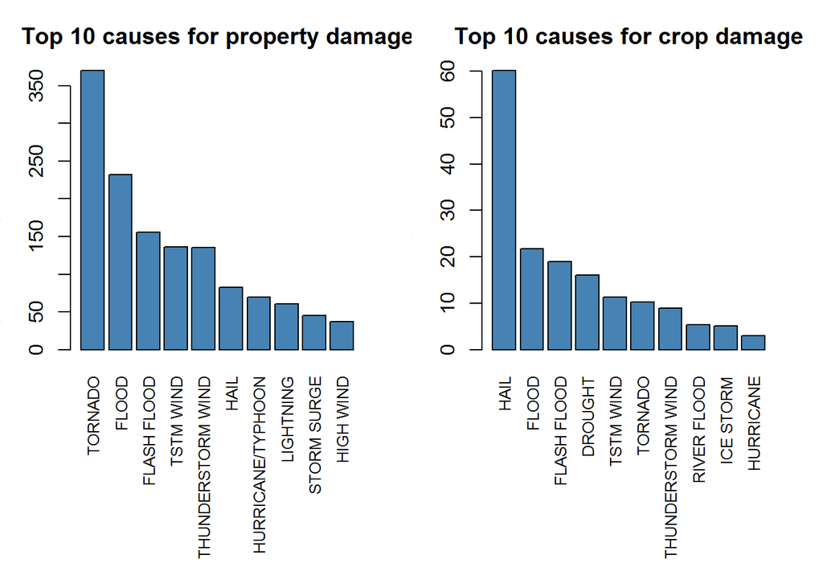

```r
propertydamagetop10 <- propertydata[1:10, ]
cropdamagetop10 <- cropdata[1:10, ]
par(mfrow = c(1, 2), mar = c(10, 3, 3, 2))
barplot(propertydamagetop10$propdmg/10^9, las = 3, names.arg = propertydamagetop10$evtype, col = "steelblue", main = "Top 10 causes for property damage", cex.names = 0.8, ylab = "Property damage (billion dollars)")
barplot(cropdamagetop10$cropdmg/10^9, las = 3, names.arg = cropdamagetop10$evtype, col = "steelblue", cex.names = 0.8, main = "Top 10 causes for crop damage", ylab = "Crop damage (billion dollars)")
```

### Public Health Impact

Let us look at the impact of severe events on fatalities and injuries.

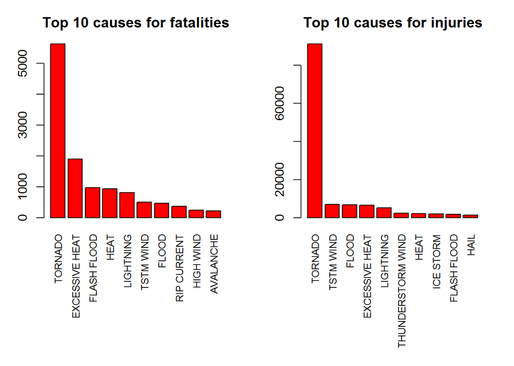

```r
fatalitiestop10 <- fatalitiesdata[1:10, ]
injuriestop10 <- injuriesdata[1:10, ]
par(mfrow = c(1, 2), mar = c(10, 3, 3, 2))
barplot(fatalitiestop10$fatalities, las = 3, cex.names = 0.8, names.arg = fatalitiestop10$evtype, col = "red", main = "Top 10 causes for fatalities", ylab = "Number of fatalities")
barplot(injuriestop10$injuries, las = 3, cex.names = 0.8, names.arg = injuriestop10$evtype, col = "red", main = "Top 10 causes for injuries", ylab = "Number of injuries")
```

## 4. Summary of results

Tornadoes are the most damaging event for fatalities, injuries and property damage while it is the 6th most damaging towards crops. Meanwhile, hail has the greatest impact on crop damage.

Some form of flood(flash/regular) consistently rank high as a damaging factor across all the categories.